# Act report

```python
import pandas as pd
import numpy as np
import matplotlib.pyplot as plt
import seaborn as sns
% matplotlib inline
master_df = pd.read_csv('twitter_archive_master.csv')
```

## The data was collected and cleaned in order to analyize it , this process was oriented by two main questions:

### 1. How was the WeRateDogs trending (deppending on like and retweet count of each tweet)?

### 2. What is the qualities(dog breed, dog stage and rating values) of the most trending rating tweet?

- The key metrics of these analyses was :
  1. Retweets count
  2. Likes count
- Qualities provided by each rating tweet:
  1. Dog breed
  2. Dog stage
  3. Rating of the dog

## Starting by the first question: 1. How was the WeRateDogs trending (deppending on like and retweet count of each tweet)?

By making a double line graph (found in wrangle_act.ipynb file) between the timestamps from data collected in the x-axis  
and retweets counts and likes counts in the y-axis I found that:

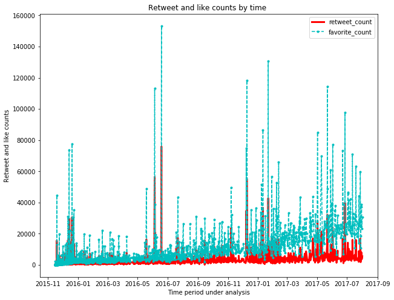

- In the interval between 2016-05 and 2016-07, WeRateDogs page was most trending.
- Also I noticed that there are generaly four intervals that the page was Trending at (have peaks in retweet and like counts,  
  those four intervals are:
  1. 2015-11 to 2016-01
  2. 2016-05 to 2016-07 (the most trendig period)
  3. 2016-11 to 2017-03
  4. 2017-05 to 2017-09

## Attempting to answer the second question: 2. What is the qualities(dog breed, dog stage and rating values) of the most trending rating tweet?

### In order to answer this question, I tried measuring every quality with the two key metrics

### #1 Finding the most trending ratings:

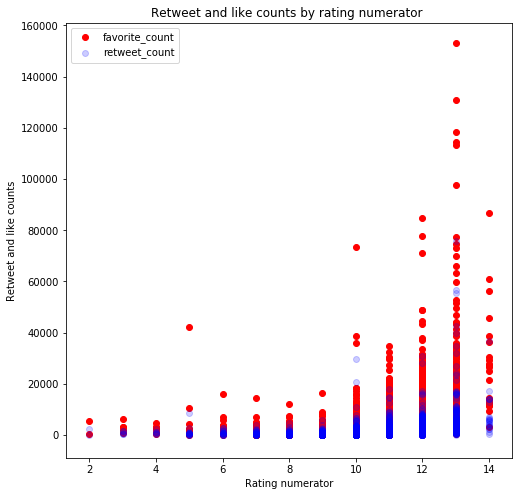

```python
retweets = master_df.retweet_count
likes = master_df.favorite_count
ratings = master_df.rating_numerator
plt.subplots(figsize=(8,8))
like_plot = plt.scatter(ratings,like,color='r', alpha= 1)
retweet_plot = plt.scatter(ratings,retweet,color='b', alpha= 0.2)
plt.title('Retweet and like counts by rating numerator ')
plt.xlabel('Rating numerator')
plt.ylabel('Retweet and like counts')
plt.legend();
```

- From the plot above we can conclude that tweets with rating equal to 13/10 are the most trending tweets (Reaches to about 160000 likes and 80000 retweets for the tweet)

### #2 Finding the most Trending dog breeds:

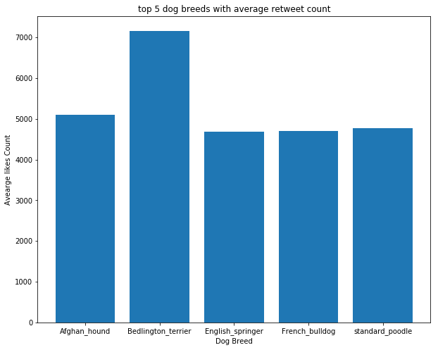

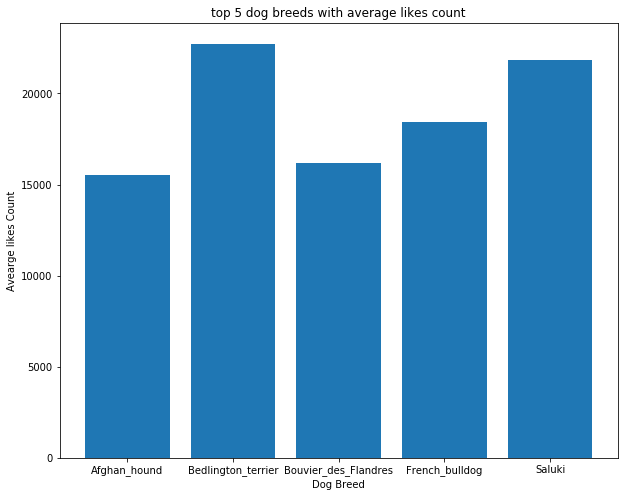

```python
top_5_retweets = master_df.groupby('dog_breed').mean().retweet_count.nlargest(5)
breed_retweets = top_5_retweets.index
plt.subplots(figsize=(10,8))
plt.bar(breed_retweets, top_5_retweets)
plt.title('top 5 dog breeds with average retweet count')
plt.xlabel('Dog Breed')
plt.ylabel('Avearge Retweet Count')
plt.title('top 5 dog breeds with average retweet count')
plt.xlabel('Dog Breed')
plt.ylabel('Avearge likes Count');
top_breed_likes = master_df.groupby('dog_breed').mean().favorite_count.nlargest(5)
breed_likes = top_breed_likes.index
plt.subplots(figsize=(10,8))
plt.bar(breed_likes, top_breed_likes)
plt.title('top 5 dog breeds with average likes count')
plt.xlabel('Dog Breed')
plt.ylabel('Avearge likes Count');
```

- From these two graphs, We can notice that the most trending dog breed was Bedlington terrier (recieved the most average like and retweet counts)

### #3 Finding the most Trending dog stages:

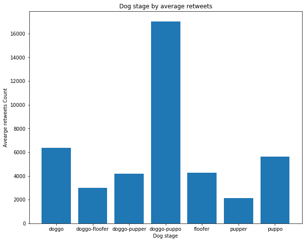

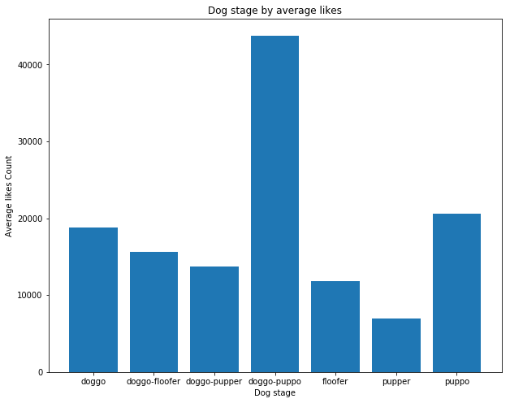

```python
top_stage_retweets = master_df.groupby('dog_stage').mean().retweet_count
stage_retweets = top_stage_retweets.index
plt.subplots(figsize=(10,8))
plt.bar(stage_retweets, top_stage_retweets)
plt.title('Dog stage by average retweets')
plt.xlabel('Dog stage')
plt.ylabel('Avearge retweets Count');
top_stage_likes = master_df.groupby('dog_stage').mean().favorite_count
stage_likes = top_stage_likes.index
plt.subplots(figsize=(10,8))
plt.bar(stage_likes, top_stage_likes)
plt.title('Dog stage by average likes')
plt.xlabel('Dog stage')
plt.ylabel('Average likes Count');
```

- From this insight and the one above it, we can conclude that the most trending dog stage was Dog stage between doggo and puppo (recieved the most average like and retweet counts)